# SparkR & Text Mining R i duże dane

Anna Wróblewska, PhD  
Expert Data Scietist, Allegro

2 June 2016

# schedule

- environment
- theory & history
- standard examples
- allegro notebook - transactions
- exercise: allegro category & offers
- wordCount / RDD/map/reduce
- text mining
- exercise: word clouds of offer titles
- http://www.slideshare.net/rxin/stanford-cs347-guest-lecture-apache-spark

# apache spark

[figure not shown]

Lightning-fast cluster computing

[figure not shown]

- high-level APIs in Java, Scala, Python and R
- http://spark.apache.org/docs/latest/index.html
- SparkR - only DataFrames API

# install SparkR

- hadoop / apache spark / SparkR
- mac os: http://www.r-bloggers.com/six-lines-to-install-and-start-sparkr-on-mac-os-x-yosemite/
- windows: http://www.r-bloggers.com/installing-and-starting-sparkr-locally-on-windows-os-and-rstudio-2/
- known issue: https://issues.apache.org/jira/browse/SPARK-13525
- jupyter notebooks: http://jupyter.readthedocs.io/en/latest/install.html  
  https://github.com/IRkernel/IRkernel

# SparkR history

- https://amplab-extras.github.io/SparkR-pkg/, RDD/map/reduce  
  NOTE: As of April 2015, SparkR has been officially merged into Apache Spark and is shipping in an upcoming release (1.4) due early summer 2015.  
  NOTE: The API from the upcoming Spark release (1.4) will not have the same API as described here. Initial support for Spark in R be focussed on high level operations instead of low level ETL. This may change in the (1.5) version.
- docs: https://amplab-extras.github.io/SparkR-pkg/rdocs/1.2/index.html  
  SparkR:::
- latest/docs DataFrames API: http://spark.apache.org/docs/latest/api/R/index.html
- http://spark.apache.org/docs/latest/sparkr.html
- https://www.gitbook.com/book/jaceklaskowski/mastering-apache-spark/details

# RDD concept

RDD - resilient distributed dataset

- collection of objects spread across a cluster, stored in RAM or Disk
- built through parallel transformation
- automatically rebuilt on failure  
  Transformations: f(RDD)=> RDD
- lazy
- e.g. map, filter, groupBy  
  Actions
- trigger computation
- e.g. collect, save, count

# DataFrames

- RDD + schema
- faster implementation
- execution lazy, query optimizer

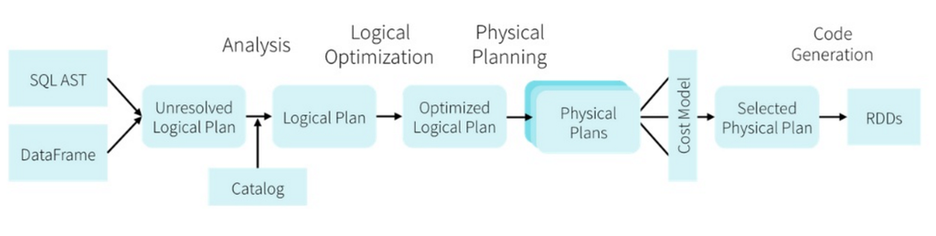

  by databricks
- join/filter

# RDD vs. DataFrames - code

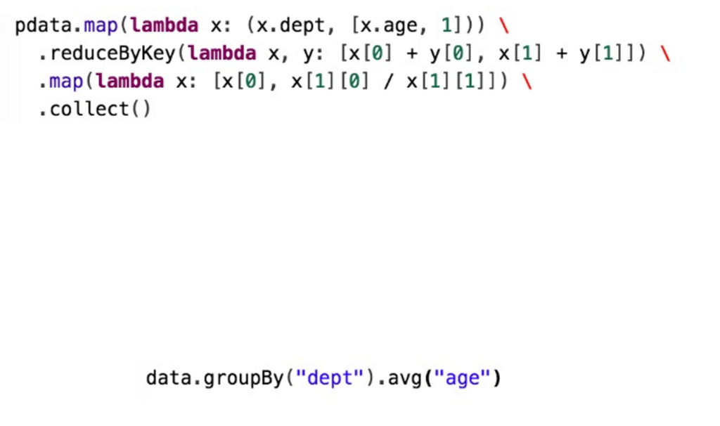

# spark context (1/2)

```r
# Get your spark path
spark_path <-strsplit(system("brew info apache-spark",intern=T)[4],' ')[[1]][1]
Sys.setenv(SPARK_HOME = file.path(spark_path,"libexec"))
print(file.path(spark_path,"libexec"))
```

```
## [1] "/usr/local/Cellar/apache-spark/1.6.1/libexec"
```

```r
# Navigate to SparkR folder
.libPaths(c(file.path(spark_path,"libexec", "R", "lib"), .libPaths()))
#load the Sparkr library
library(SparkR)
```

# spark context (2/2)

```r
sparkEnvir <- list(
  #spark.yarn.queue = 'mi_prod',
  spark.executor.memory = '2g',
  spark.executor.instances = '20',
  spark.yarn.driver.memoryOverhead = '1024',
  spark.yarn.executor.memoryOverhead = '1024',
  spark.driver.extraJavaOptions='-XX:MaxPermSize=1024m'#512m'
)
sc <- sparkR.init( appName = 'test R', master ="local[2]", sparkEnvir = sparkEnvir)
```

```
## Launching java with spark-submit command /usr/local/Cellar/apache-spark/1.6.1/libexec/bin/spark-submit   --driver-java-options "-XX:MaxPermSize=1024m" sparkr-shell /var/folders/c9/1767gnvj6zbct69ggtlp1stnj44wrx/T//Rtmpi4WWzy/backend_port6bef4909035d
```

```r
sqlContext <- sparkRSQL.init(sc)
```

…  
INFO SparkUI: Started SparkUI at http://localhost:4040  
http://spark.apache.org/docs/latest/sparkr.html#starting-up-from-rstudio

# check SparkR on your machine

```r
#create a sparkR DataFrame
DF <- createDataFrame(sqlContext, faithful)
head(DF)
```

```
##   eruptions waiting
## 1     3.600      79
## 2     1.800      54
## 3     3.333      74
## 4     2.283      62
## 5     4.533      85
## 6     2.883      55
```

```r
sparkR.stop()
```

# data sources: CSV

https://github.com/databricks/spark-csv  
http://mvnrepository.com/artifact/com.databricks/spark-csv_2.11

```r
library(SparkR)
Sys.setenv('SPARKR_SUBMIT_ARGS'='"--packages" "com.databricks:spark-csv_2.11:1.4.0" "sparkr-shell"')
sc <- sparkR.init( appName = 'test R', master ="local[2]", sparkEnvir = sparkEnvir)
```

```r
library(SparkR)
sc <- sparkR.init( appName = 'test R', master ="local[2]", sparkEnvir = sparkEnvir, sparkPackages="com.databricks:spark-csv_2.11:1.4.0")
```

- json, parquet, avro, hive, …

# apache sparkR examples

Let’s go through apache sparkR examples:  
SPARK_HOME / examples  
- data-manipulation.R  
- dataframe.R  
- ml.R  
http://spark.apache.org/docs/latest/api/R/index.html  
https://cwiki.apache.org/confluence/display/Hive/LanguageManual+Select

# allegro categories

1. read file as a data frame
2. print schema
3. print statistics
4. change column type: ca_level
5. która kategoria główna ma najwięcej podkategorii?
6. która kategoria ma najbardziej zagłębione drzewo?
7. ile jest podkategorii w każdej kategorii głównej?
8. min, max, średni poziom zagłębienia kategorii w kategorii głównej
9. ile jest kategorii 3-go poziomu?

# transaction data in allegro

- dataFrames na danych transakcji z allegro

# RDD in SparkR

- old sparkR docs: https://amplab-extras.github.io/SparkR-pkg/rdocs/1.2/index.html
- wordCount

```r
#pyspark: wordcounts = words.map(lambda s: (s, 1)).reduceByKey(lambda a, b : a + b).collect()
words <- SparkR:::parallelize(sc,c("hello", "world", "goodbye", "hello", "again"))
pairs <- SparkR:::map( words,function(word){ list(word,1L)} )
res <- SparkR:::reduceByKey(pairs,"+",2L)
res2 <- SparkR::collect(res)
```

[output not shown]

TODO:  
- letter count (letter, count)  
- count sum of used letters  
- use %>%

# allegro offers

- active offers in one day in category “Dom i Zdrowie” TODO:
1. ile jest ofert w kategorii 3-go poziomu
2. statystyki cen ofert w kategoriach
3. chmura tagów z nazw ofert w kategoriach

# Text Mining in R

packages: tm, wordcloud, NLP, SnowballC - text document matrix - term frequency - TF-IDF https://cran.r-project.org/web/packages/tm/tm.pdf

# Other sources

https://www.codementor.io/spark/tutorial/spark-r-data-frame-operations-sql